# Google data analytics capstone project report

Andrés Peña

2/17/2022

**USING TIDYVERSE PACKAGE**  
First of all to begin the analysis we need to *understand* the structure of the data frame

```r
str(consolidated_2021)
```

```
## spec_tbl_df [5,595,063 x 13] (S3: spec_tbl_df/tbl_df/tbl/data.frame)
##  $ ride_id           : chr [1:5595063] "E19E6F1B8D4C42ED" "DC88F20C2C55F27F" "EC45C94683FE3F27" "4FA453A75AE377DB" ...
##  $ rideable_type     : chr [1:5595063] "electric_bike" "electric_bike" "electric_bike" "electric_bike" ...
##  $ started_at        : POSIXct[1:5595063], format: "2021-01-23 16:14:19" "2021-01-27 18:43:08" ...
##  $ ended_at          : POSIXct[1:5595063], format: "2021-01-23 16:24:44" "2021-01-27 18:47:12" ...
##  $ start_station_name: chr [1:5595063] "California Ave & Cortez St" "California Ave & Cortez St" "California Ave & Cortez St" "California Ave & Cortez St" ...
##  $ start_station_id  : chr [1:5595063] "17660" "17660" "17660" "17660" ...
##  $ end_station_name  : chr [1:5595063] NA NA NA NA ...
##  $ end_station_id    : chr [1:5595063] NA NA NA NA ...
##  $ start_lat         : num [1:5595063] 41.9 41.9 41.9 41.9 41.9 ...
##  $ start_lng         : num [1:5595063] -87.7 -87.7 -87.7 -87.7 -87.7 ...
##  $ end_lat           : num [1:5595063] 41.9 41.9 41.9 41.9 41.9 ...
##  $ end_lng           : num [1:5595063] -87.7 -87.7 -87.7 -87.7 -87.7 ...
##  $ member_casual     : chr [1:5595063] "member" "member" "member" "member" ...
##  - attr(*, "spec")=
##   .. cols(
##   ..   ride_id = col_character(),
##   ..   rideable_type = col_character(),
##   ..   started_at = col_datetime(format = ""),
##   ..   ended_at = col_datetime(format = ""),
##   ..   start_station_name = col_character(),
##   ..   start_station_id = col_character(),
##   ..   end_station_name = col_character(),
##   ..   end_station_id = col_character(),
##   ..   start_lat = col_double(),
##   ..   start_lng = col_double(),
##   ..   end_lat = col_double(),
##   ..   end_lng = col_double(),
##   ..   member_casual = col_character()
##   .. )
##  - attr(*, "problems")=<externalptr>
```

The str() function helps the process of analyzing the data frame highlighting the names of the columns and the type of data they contain.

```r
summary(consolidated_2021)
```

```
##    ride_id          rideable_type        started_at
##  Length:5595063     Length:5595063     Min.   :2021-01-01 00:02:05
##  Class :character   Class :character   1st Qu.:2021-06-06 23:52:40
##  Mode  :character   Mode  :character   Median :2021-08-01 01:52:11
##                                        Mean   :2021-07-29 07:41:02
##                                        3rd Qu.:2021-09-24 16:36:16
##                                        Max.   :2021-12-31 23:59:48
##
##     ended_at                   start_station_name start_station_id
##  Min.   :2021-01-01 00:08:39   Length:5595063     Length:5595063
##  1st Qu.:2021-06-07 00:44:21   Class :character   Class :character
##  Median :2021-08-01 02:21:55   Mode  :character   Mode  :character
##  Mean   :2021-07-29 08:02:58
##  3rd Qu.:2021-09-24 16:54:05
##  Max.   :2022-01-03 17:32:18
##
##  end_station_name   end_station_id       start_lat       start_lng
##  Length:5595063     Length:5595063     Min.   :41.64   Min.   :-87.84
##  Class :character   Class :character   1st Qu.:41.88   1st Qu.:-87.66
##  Mode  :character   Mode  :character   Median :41.90   Median :-87.64
##                                        Mean   :41.90   Mean   :-87.65
##                                        3rd Qu.:41.93   3rd Qu.:-87.63
##                                        Max.   :42.07   Max.   :-87.52
##
##     end_lat         end_lng       member_casual
##  Min.   :41.39   Min.   :-88.97   Length:5595063
##  1st Qu.:41.88   1st Qu.:-87.66   Class :character
##  Median :41.90   Median :-87.64   Mode  :character
##  Mean   :41.90   Mean   :-87.65
##  3rd Qu.:41.93   3rd Qu.:-87.63
##  Max.   :42.17   Max.   :-87.49
##  NA's   :4771    NA's   :4771
```

The summary() function is very similar in that it returns the names of the columns and the type of data they contain but with extra relevant information such as the median for numeric columns, also the min. and max. values for the data types that apply.

```r
length(unique(consolidated_2021$ride_id)) == nrow(consolidated_2021)
```

```
## [1] TRUE
```

This chunk of code is used to see if there are any duplicates in the ride_id column, which just so happens to be the primary key for the entire data frame, meaning the values should be unique for each row and there should not be any duplicates if the data frame used is completely clean.

```r
consolidated_2021 <- cbind(consolidated_2021, time_riding = as.numeric(consolidated_2021$ended_at - consolidated_2021$started_at)/60)
```

This code chunk is used specifically to create a new column that shows the time spent on each individual ride, it is going to help reveal some key information later on in the analysis.

```r
sum(is.na(consolidated_2021$ride_id))
```

```
## [1] 0
```

```r
sum(is.na(consolidated_2021$rideable_type))
```

```
## [1] 0
```

```r
sum(is.na(consolidated_2021$member_casual))
```

```
## [1] 0
```

```r
sum(is.na(consolidated_2021$time_riding))
```

```
## [1] 0
```

Here, this code chunk is used to check to check for NA values in the more sensitive data columns. We see that the output for each line of code is 0, so it is correct to say that there are no NA values in the aforementioned columns.

```r
casual_members=filter(consolidated_2021,member_casual=='casual'& time_riding < 600 & time_riding > 0)
annual_members=filter(consolidated_2021,member_casual=='member'& time_riding < 600 & time_riding > 0)
```

This code chunk is used to filter out the data frame according to the type of member. This is basic to conduct the casual vs. annual member comparison.

```r
perc_1 <- count(annual_members)/count(consolidated_2021)*100
print(perc_1)
```

```
##          n
## 1 54.77225
```

```r
perc_2 <- 100-perc_1
print(perc_2)
```

```
##          n
## 1 45.22775
```

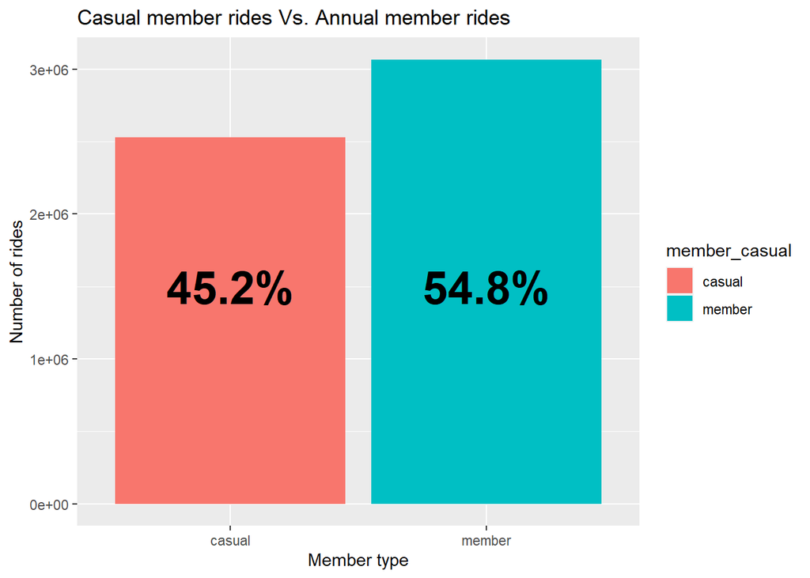

```r
ggplot(data=consolidated_2021) +
  geom_bar(mapp=aes(x=member_casual , fill=member_casual)) +
  labs(title="Casual member rides Vs. Annual member rides") +
  annotate("text", x=1, y=1500000, label="45.2%", size=10, fontface= "bold") +
  annotate("text", x=2, y=1500000, label="54.8%", size=10, fontface= "bold") +
  ylab("Number of rides") +
  xlab("Member type")
```

Out of the graph we can easily tell that annual members made more rides in the year of 2021. Based on this percentage, the marketing department can set future goals for their marketing plan. Given that their objective is to convert casual riders to annual members, it would be reasonable to aim for a 60% 40% or 65% 35% goal for the next year.

```r
mean(casual_members$time_riding)
```

```
## [1] 25.64116
```

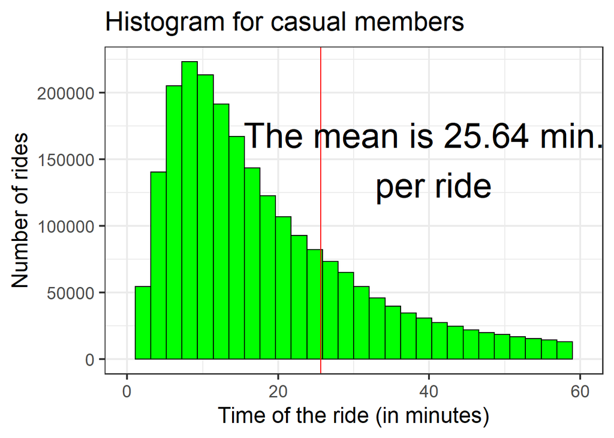

```r
ggplot(data=casual_members)+
  geom_histogram(bins=30,color= "black", fill="green")+
  aes(x=time_riding)+
  xlim(0,60)+
  theme_bw(base_size = 18)+
  xlab("Time of the ride (in minutes)")+
  ylab("Number of rides")+
  ggtitle("Histogram for casual members")+
  geom_vline(aes(xintercept = mean(time_riding)), color= "red") +
  annotate("text",x=40, y=150000, label= "The mean is 25.64 min. \n per ride", size =10)
```

As seen in the graph, the highest concentration of time for the rides happens between 0 and 20 minutes, and the distribution starts diminishing as time increases. It is also very important to highlight the mean of the group being 25.64 minutes per ride because that is going to function as the comparing factor between casual and annual rides. For the annual member rides we see the following:

```r
mean(annual_members$time_riding)
```

```
## [1] 13.19072
```

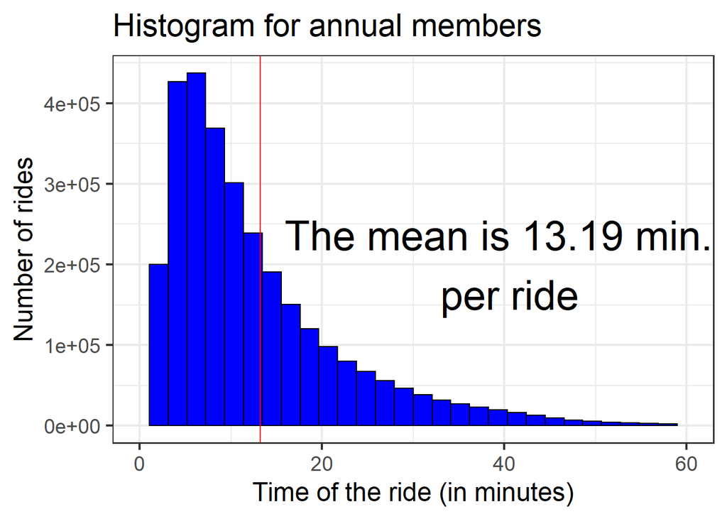

```r
ggplot(data=annual_members)+
  geom_histogram(bins=30,color= "black", fill="blue")+
  aes(x=time_riding)+
  xlim(0,60)+
  theme_bw(base_size = 18)+
  xlab("Time of the ride (in minutes)")+
  ylab("Number of rides")+
  ggtitle("Histogram for annual members")+
  geom_vline(aes(xintercept = mean(time_riding)), color= "red")+
  annotate("text",x=40, y=200000, label= "The mean is 13.19 min. \n per ride", size =10)
```

In the annual histogram there is a higher concentration in the lower time limits, and we can also see a steeper decline towards the higher time marks. The mean for the time spent in each ride is 13.19 minutes which is almost half of the mean for casual member ride time. Based on that, we can assume that casual riders tend to stay on longer rides, because tourists fall in that group. Making longer and longer trips to get to know the rest of the city.

```
After those comparisons are made, we proceed to compare the bike type usage, just to check if there are any wild discrepancies to guide us better through the analyze phase.  This is the outcome:
```

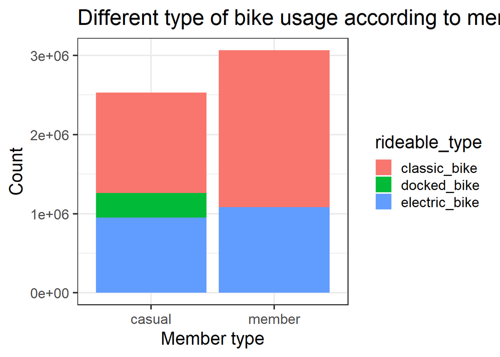

```r
ggplot(data=consolidated_2021)+
  geom_bar(aes(x=member_casual, fill=rideable_type))+
  theme_bw(base_size = 18)+
  ggtitle("Different type of bike usage according to member type")+
  xlab("Member type")+
  ylab("Count")
```

```r
myvars <- c("start_lat","start_lng")
start_casual <- casual_members[myvars]
start_casual <- drop_na(start_casual)

mean.longitude <- mean(start_casual$start_lng)
mean.latitude <- mean(start_casual$start_lat)

chicago_map<- get_map(location = c(mean.longitude, mean.latitude), zoom = 13, scale = 2)
```

[figure not shown]

[output not shown]

```r
chicago_map <- ggmap(chicago_map, extent="device", legend="none")
chicago_map <- chicago_map + stat_density2d(data=start_casual,
                                        aes(x=start_lng, y=start_lat, fill=..level.., alpha=10), geom="polygon")

chicago_map <- chicago_map + scale_fill_gradientn(colours=rev(brewer.pal(7, "Spectral")))

plot(chicago_map)
```